# Постановка задачи

**Цель проекта:** проанализировать базу данных.

В ней — информация о книгах, издательствах, авторах, а также пользовательские обзоры книг. Эти данные помогут сформулировать ценностное предложение для нового продукта.

# Задания проекта

- Посчитайте, сколько книг вышло после 1 января 2000 года;
- Для каждой книги посчитайте количество обзоров и среднюю оценку;
- Определите издательство, которое выпустило наибольшее число книг толще 50 страниц — так вы исключите из анализа брошюры;
- Определите автора с самой высокой средней оценкой книг — учитывайте только книги с 50 и более оценками;
- Посчитайте среднее количество обзоров от пользователей, которые поставили больше 50 оценок.

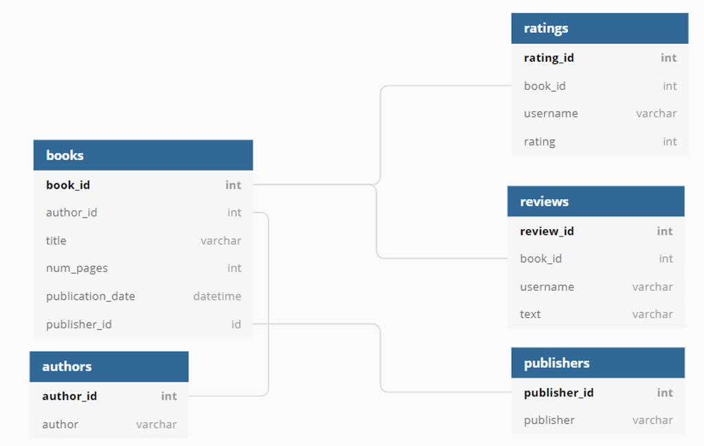

## Подготовка к анализу

```python
import pandas as pd
from sqlalchemy import create_engine
```

```python
# устанавливаем параметры
db_config = {'user': 'praktikum_student', # имя пользователя
'pwd': 'Sdf4$2;d-d30pp', # пароль
'host': 'rc1b-wcoijxj3yxfsf3fs.mdb.yandexcloud.net',
'port': 6432, # порт подключения
'db': 'data-analyst-final-project-db'} # название базы данных

connection_string = 'postgresql://{}:{}@{}:{}/{}'.format(db_config['user'],
db_config['pwd'],
db_config['host'],
db_config['port'],
db_config['db'])

# сохраняем коннектор
engine = create_engine(connection_string, connect_args={'sslmode':'require'})
```

## Исследование данных

```python
#запрос таблицы
query = '''
SELECT *
FROM books
'''

books = pd.io.sql.read_sql(query, con = engine)
display(books.duplicated().sum())
display(books.isna().sum())
books
```

```
0
```

```
book_id             0
author_id           0
title               0
num_pages           0
publication_date    0
publisher_id        0
dtype: int64
```

|  | book_id | author_id | title | num_pages | publication_date | publisher_id |
| --- | --- | --- | --- | --- | --- | --- |
| 0 | 1 | 546 | 'Salem's Lot | 594 | 2005-11-01 | 93 |
| 1 | 2 | 465 | 1 000 Places to See Before You Die | 992 | 2003-05-22 | 336 |
| 2 | 3 | 407 | 13 Little Blue Envelopes (Little Blue Envelope... | 322 | 2010-12-21 | 135 |
| 3 | 4 | 82 | 1491: New Revelations of the Americas Before C... | 541 | 2006-10-10 | 309 |
| 4 | 5 | 125 | 1776 | 386 | 2006-07-04 | 268 |
| ... | ... | ... | ... | ... | ... | ... |
| 995 | 996 | 571 | Wyrd Sisters (Discworld #6; Witches #2) | 265 | 2001-02-06 | 147 |
| 996 | 997 | 454 | Xenocide (Ender's Saga #3) | 592 | 1996-07-15 | 297 |
| 997 | 998 | 201 | Year of Wonders | 358 | 2002-04-30 | 212 |
| 998 | 999 | 94 | You Suck (A Love Story #2) | 328 | 2007-01-16 | 331 |
| 999 | 1000 | 509 | Zen and the Art of Motorcycle Maintenance: An ... | 540 | 2006-04-25 | 143 |

1000 rows × 6 columns

Как мы видим в таблице books 1000 записей о книгах. Пропуски и дубликаты отсутствуют.

```python
#запрос таблицы
query = '''
SELECT *
FROM authors
'''

authors = pd.io.sql.read_sql(query, con = engine)
display(authors.duplicated().sum())
display(authors.isna().sum())
authors
```

```
0
```

```
author_id    0
author       0
dtype: int64
```

|  | author_id | author |
| --- | --- | --- |
| 0 | 1 | A.S. Byatt |
| 1 | 2 | Aesop/Laura Harris/Laura Gibbs |
| 2 | 3 | Agatha Christie |
| 3 | 4 | Alan Brennert |
| 4 | 5 | Alan Moore/David Lloyd |
| ... | ... | ... |
| 631 | 632 | William Strunk Jr./E.B. White |
| 632 | 633 | Zadie Smith |
| 633 | 634 | Zilpha Keatley Snyder |
| 634 | 635 | Zora Neale Hurston |
| 635 | 636 | Åsne Seierstad/Ingrid Christopherson |

636 rows × 2 columns

В таблице authors 636 записей об авторах. Пропусков и дубликатов не обнаружено.

```python
#запрос таблицы
query = '''
SELECT *
FROM ratings
'''

ratings = pd.io.sql.read_sql(query, con = engine)
display(ratings.duplicated().sum())
display(ratings.isna().sum())
ratings
```

```
0
```

```
rating_id    0
book_id      0
username     0
rating       0
dtype: int64
```

|  | rating_id | book_id | username | rating |
| --- | --- | --- | --- | --- |
| 0 | 1 | 1 | ryanfranco | 4 |
| 1 | 2 | 1 | grantpatricia | 2 |
| 2 | 3 | 1 | brandtandrea | 5 |
| 3 | 4 | 2 | lorichen | 3 |
| 4 | 5 | 2 | mariokeller | 2 |
| ... | ... | ... | ... | ... |
| 6451 | 6452 | 1000 | carolrodriguez | 4 |
| 6452 | 6453 | 1000 | wendy18 | 4 |
| 6453 | 6454 | 1000 | jarvispaul | 5 |
| 6454 | 6455 | 1000 | zross | 2 |
| 6455 | 6456 | 1000 | fharris | 5 |

6456 rows × 4 columns

В таблице ratings 6456 записей с рейтингами пользователей. Пропуски и дубликаты отсутствуют.

```python
#запрос таблицы
query = '''
SELECT *
FROM reviews
'''

reviews = pd.io.sql.read_sql(query, con = engine)
display(reviews.duplicated().sum())
display(reviews.isna().sum())
reviews
```

```
0
```

```
review_id    0
book_id      0
username     0
text         0
dtype: int64
```

|  | review_id | book_id | username | text |
| --- | --- | --- | --- | --- |
| 0 | 1 | 1 | brandtandrea | Mention society tell send professor analysis. ... |
| 1 | 2 | 1 | ryanfranco | Foot glass pretty audience hit themselves. Amo... |
| 2 | 3 | 2 | lorichen | Listen treat keep worry. Miss husband tax but ... |
| 3 | 4 | 3 | johnsonamanda | Finally month interesting blue could nature cu... |
| 4 | 5 | 3 | scotttamara | Nation purpose heavy give wait song will. List... |
| ... | ... | ... | ... | ... |
| 2788 | 2789 | 999 | martinadam | Later hospital turn easy community. Fact same ... |
| 2789 | 2790 | 1000 | wknight | Change lose answer close pressure. Spend so now. |
| 2790 | 2791 | 1000 | carolrodriguez | Authority go who television entire hair guy po... |
| 2791 | 2792 | 1000 | wendy18 | Or western offer wonder ask. More hear phone f... |
| 2792 | 2793 | 1000 | jarvispaul | Republican staff bit eat material measure plan... |

2793 rows × 4 columns

В таблице reviews 2793 записей с отзывами. Пропусков и дубликатов нет.

```python
#запрос таблицы
query = '''
SELECT *
FROM publishers
'''

publishers = pd.io.sql.read_sql(query, con = engine)
display(publishers.duplicated().sum())
display(publishers.isna().sum())
publishers
```

```
0
```

```
publisher_id    0
publisher       0
dtype: int64
```

|  | publisher_id | publisher |
| --- | --- | --- |
| 0 | 1 | Ace |
| 1 | 2 | Ace Book |
| 2 | 3 | Ace Books |
| 3 | 4 | Ace Hardcover |
| 4 | 5 | Addison Wesley Publishing Company |
| ... | ... | ... |
| 335 | 336 | Workman Publishing Company |
| 336 | 337 | Wyatt Book |
| 337 | 338 | Yale University Press |
| 338 | 339 | Yearling |
| 339 | 340 | Yearling Books |

340 rows × 2 columns

В таблице publishers 340 записей об издателях. Пропусков и дубликатов не обнаружено.

Данные чисты и готовы к анализу.

## Задание №1

**Посчитайте, сколько книг вышло после 1 января 2000 года;**

```python
#запрос таблицы
query = '''
SELECT COUNT(book_id)
FROM books
WHERE DATE_TRUNC('day',publication_date::date) > '2000-01-01'
'''

output = pd.io.sql.read_sql(query, con = engine)
output
```

|  | count |
| --- | --- |
| 0 | 819 |

После 1 января 2000 года вышло 819 книг.

## Задание №2

**Для каждой книги посчитайте количество обзоров и среднюю оценку;**

```python
#запрос таблицы
query = '''
SELECT b.book_id,
b.title,
COUNT(DISTINCT(r.review_id)),
AVG(ra.rating)
FROM books AS b
FULL JOIN reviews AS r ON b.book_id = r.book_id
FULL JOIN ratings AS ra ON ra.book_id = b.book_id
GROUP BY b.book_id
'''

output = pd.io.sql.read_sql(query, con = engine)
output
```

|  | book_id | title | count | avg |
| --- | --- | --- | --- | --- |
| 0 | 1 | 'Salem's Lot | 2 | 3.666667 |
| 1 | 2 | 1 000 Places to See Before You Die | 1 | 2.500000 |
| 2 | 3 | 13 Little Blue Envelopes (Little Blue Envelope... | 3 | 4.666667 |
| 3 | 4 | 1491: New Revelations of the Americas Before C... | 2 | 4.500000 |
| 4 | 5 | 1776 | 4 | 4.000000 |
| ... | ... | ... | ... | ... |
| 995 | 996 | Wyrd Sisters (Discworld #6; Witches #2) | 3 | 3.666667 |
| 996 | 997 | Xenocide (Ender's Saga #3) | 3 | 3.400000 |
| 997 | 998 | Year of Wonders | 4 | 3.200000 |
| 998 | 999 | You Suck (A Love Story #2) | 2 | 4.500000 |
| 999 | 1000 | Zen and the Art of Motorcycle Maintenance: An ... | 4 | 3.833333 |

1000 rows × 4 columns

Получаем таблицу с количеством обзоров и средней оценкой каждой книги.

## Задание №3

**Определите издательство, которое выпустило наибольшее число книг толще 50 страниц — так вы исключите из анализа брошюры;**

```python
#запрос таблицы
query = '''
SELECT p.publisher_id,
p.publisher,
COUNT(b.book_id) AS count_of_books
FROM books AS b
LEFT JOIN publishers AS p ON b.publisher_id = p.publisher_id
WHERE b.num_pages > 50
GROUP BY p.publisher_id
ORDER BY count_of_books DESC
LIMIT 1
'''

output = pd.io.sql.read_sql(query, con = engine)
output
```

|  | publisher_id | publisher | count_of_books |
| --- | --- | --- | --- |
| 0 | 212 | Penguin Books | 42 |

Издатель Penguin Books выпустил наибольшее количество книг - 42 издания, которые толще 50 страниц.

## Задание №4

**Определите автора с самой высокой средней оценкой книг — учитывайте только книги с 50 и более оценками;**

```python
#запрос таблицы
query = '''
SELECT t.author,
AVG(avg)
FROM
(SELECT b.book_id,
a.author_id,
a.author,
COUNT(ra.rating),
AVG(ra.rating)
FROM books AS b
LEFT JOIN authors AS a ON b.author_id = a.author_id
LEFT JOIN ratings AS ra ON b.book_id = ra.book_id
GROUP BY b.book_id,a.author_id
HAVING COUNT(ra.rating) >= 50) AS t
GROUP BY t.author
ORDER BY avg DESC
'''
output = pd.io.sql.read_sql(query, con = engine)
output
```

|  | author | avg |
| --- | --- | --- |
| 0 | J.K. Rowling/Mary GrandPré | 4.283844 |
| 1 | Markus Zusak/Cao Xuân Việt Khương | 4.264151 |
| 2 | J.R.R. Tolkien | 4.258446 |
| 3 | Louisa May Alcott | 4.192308 |
| 4 | Rick Riordan | 4.080645 |
| 5 | William Golding | 3.901408 |
| 6 | J.D. Salinger | 3.825581 |
| 7 | Paulo Coelho/Alan R. Clarke/Özdemir İnce | 3.789474 |
| 8 | William Shakespeare/Paul Werstine/Barbara A. M... | 3.787879 |
| 9 | Dan Brown | 3.754540 |
| 10 | Lois Lowry | 3.750000 |
| 11 | George Orwell/Boris Grabnar/Peter Škerl | 3.729730 |
| 12 | Stephenie Meyer | 3.662500 |
| 13 | John Steinbeck | 3.622951 |

Как мы видим автором с самой высокой средней оценкой является Джоан Роулинг c оценкой в 4.3 балла.

## Задание №5

**Посчитайте среднее количество обзоров от пользователей, которые поставили больше 50 оценок.**

```python
#запрос таблицы
query = '''
SELECT AVG(count)
FROM(SELECT COUNT(review_id)
FROM reviews
WHERE username in (SELECT username
FROM ratings
GROUP BY username
HAVING COUNT(rating) > 50)
GROUP BY username) AS t
'''
output = pd.io.sql.read_sql(query, con = engine)
output
```

|  | avg |
| --- | --- |
| 0 | 24.333333 |

Как мы видим пользователи, поставившие больше 50 оценок в среднем пишут 24 обзора.

## Выводы

Был проведен анализ, для каждой из задач написан запрос. Подытожим результаты: 1) После 1 января 2000 года вышло 819 книг.

2) Построена таблица с количеством обзоров и средней оценкой каждой книги.

3) Издатель Penguin Books выпустил наибольшее количество книг - 42 издания, которые толще 50 страниц.

4) Джоан Роулинг имеет наибольший средний рейтинг среди авторов, ее оценка 4.3 балла.

5) Пользователи, которые поставили больше 50 оценок в среднем пишут 24 обзора.